# Hii, I'm Shreyash

## This is Numpy

### Let's import Numpy

```python
import numpy as np
```

### Make an array in numpy specifying the data type

##### Numpy suppports different types of data type to make our data sufficient enogh Like int8, int16, int32, int64

```python
a=np.array([1, 3, 3], dtype='int8')
print(a)
```

```
[1 3 3]
```

### Multidimensional Array

```python
b=np.array([[1, 3, 5], [2, 3, 5]])
print(b)
```

```
[[1 3 5]
 [2 3 5]]
```

### Shape of the array changing

##### Make sure the size of the array remains same in sort no element would be inserted or deleted during this process

```python
b.shape=(1,6)
print(b)
```

```
[[1 3 5 2 3 5]]
```

```python
b.shape=(3, 2)
print(b)
```

```
[[1 3]
 [5 2]
 [3 5]]
```

### To know the data type of the numbers or data rather the array is containing

```python
print(a.dtype)
```

```
int8
```

### Size of the entire array

##### These are the two ways to this arraysize*itemsize or by using nbytes.

```python
print(a.size*a.itemsize,
a.nbytes)
```

```
3 3
```

### Accesign info in the array using :o

###### [Start Index: End Index: Step Size]

```python
b[2, :]
```

```
array([3, 5])
```

### Repeat Things in the array

##### In below code array b is being repeated 3 times with the axis 1 meaning it will make array of size [1, 9]

```python
b=np.array([[1, 2, 3]])
c=np.repeat(b, 3, axis=1)
print(c[0, ::2])
```

```
[1 1 2 3 3]
```

### filling an array with random values

##### The below code does create random decimal numbers using random module in numpy of size [4, 2]

###### For random Int can use np.random.randint(val1, val2, size=(x,y)) where val1 is lowerbound , val2 is upperboud and size=(x, y) specifies an array to be made.

```python
b[:, ::1]=[[1, 4, 5]]
d=np.random.rand(4,2)
print(d)
```

```
[[0.42195762 0.86498204]
 [0.91341263 0.33204442]
 [0.75985235 0.28298197]
 [0.69252822 0.57118244]]
```

### Full to fill the Araay with some values

###### Ask someone about it.

```python
c.shape=(3, 3)
x=np.full(c[1, ], 4)
print(c, " and ",x)
```

```
[[1 1 1]
 [2 2 2]
 [3 3 3]]  and  [[[4 4]
  [4 4]]

 [[4 4]
  [4 4]]]
```

###### Excercise: Create this array

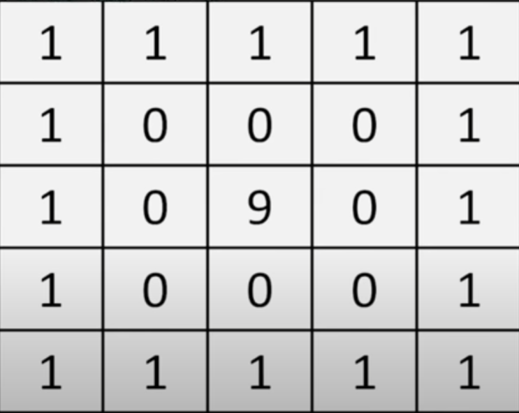